Back to Data Analytics Projects

# From the Field to the Classroom: A Look at the Majors of Division 1 Football Players

Samuel Gonzalez III

Tuesday April 4, 2023

# Introduction

Division 1 Football players are often stereotyped as taking easy majors to maintain their athletic commitments. But is this stereotype rooted in reality? Through a data-driven analysis of the academic paths of Division 1 Football players, this article seeks to explore the true spread of majors among some of the most prominent teams in college football. By examining patterns in major choice and comparing them to these stereotypes, this analysis aims to shed light on the academic paths of student-athletes and discussing the reality of commonly held beliefs.

As a former Football player, I often encountered this stereotype that athletes take the “easy road” when it comes to academics. This belief has fueled my curiosity to explore the academic paths of my fellow student-athletes and understand if this stereotype holds true. Through data analysis of the spread of majors among Division 1 Football players, this article aims to answer questions around the academic choices of college athletes. Do student-athletes choose majors based on their athletic commitments or for the potential of a future career? How do the schedules of student-athletes affect their academic choices?

# Data and Methodology

The purpose of this study is to examine the spread of majors among Division 1 Football players. To collect data, I used the online rosters of 10 college football programs that publicly disclose the majors of their athletes. The programs were chosen based on their ranking in the top 25, with the first 10 teams that disclose their major information being selected. The data was obtained using a Python program that I designed to scrape information from the websites. Here are the 10 schools that were chosen.

- [#1. University of Georgia](https://georgiadogs.com/sports/football)
- [#4. The Ohio State University](https://ohiostatebuckeyes.com/sports/m-footbl/)
- [#6. University of Tennessee](https://utsports.com/sports/football)
- [#7. Pennsylvania State University](https://gopsusports.com/sports/football)
- [#9. Tulane University](https://tulanegreenwave.com/sports/football)
- [#10. University of Utah](https://utahutes.com/sports/football)
- [#13. Clemson University](https://clemsontigers.com/sports/football/)
- [#14. Kansas State University](https://www.kstatesports.com/sports/football)
- [#17. Oregon State University](https://osubeavers.com/sports/football)
- [#25. University of Texas](https://texassports.com/sports/football)

The information that I was after on these roster pages was each athletes, name, major, class, hometown, and school. Across the 10 programs included in this analysis, a total of over 1000 athletes were examined. I chose these variables because they provide a comprehensive picture of the athletes academic and athletic profiles, and because they are readily available on the public roster pages.

While developing my Python program, I encountered challenges as most schools had different website layouts that made it difficult to locate and obtain certain information. Consequently, I had to write custom scripts for each school, but fortunately, they all followed a similar structure, making the process much faster and reusable in the future. As an example, here is a script for the Oregon State roster in the program.

```python
# Main.py

import pandas as pd
import UGARoster as UGA
import OregonStateRoster as OregonState
import TexasRoster as Texas

def export_data_frame_to_excel(dataFrame, name):
  try:
    print('Exporting to excel...')
    downloadURL = '~/Downloads/' + name + '.csv'
    dataFrame.to_csv(downloadURL, index=False)
    print('...Finished')
  except:
    print('Failure exporting to excel')

if __name__ == '__main__':

    rosterData = pd.DataFrame()

    UGAData = UGA.get_info()
    rosterData = rosterData.append(UGAData)

    ...

    OregonStateData = OregonState.get_info()
    rosterData = rosterData.append(OregonStateData)

    TexasData = Texas.get_info()
    rosterData = rosterData.append(TexasData)

    rosterData['Class'] = rosterData['Class'].str.lower()
    rosterData['Major'] = rosterData['Major'].str.lower()

    export_data_frame_to_excel(rosterData, 'NCAA-Div-1-roster-info')
```

```python
# OregonStateRoster.py

import requests
from bs4 import BeautifulSoup
import pandas as pd

def get_info():

    print('Getting Oregon State Info...')
    dataFrame = {'Name': [],
                 'Major': [],
                 'Class': [],
                 'Hometown': [],
                 'School': []}
    rosterData = pd.DataFrame(dataFrame)

    try:
        url = 'https://osubeavers.com/sports/football/roster'
        response = requests.get(url)

        rosterPage = BeautifulSoup(response.text, 'html.parser')

        rosterList = rosterPage.find('div', {'class': 'c-rosterpage__players'})
        for player in rosterList.find_all('div', {'class': 's-person-card__content'}):
            href = player.find('a').get('href')
            playerInfo = get_info_from_bio(href)
            rosterData = rosterData.append(playerInfo, ignore_index=True)

        return rosterData
    except:
        print('Failure in Oregon State get_info()')


def get_info_from_bio(href):
    try:
        url = 'https://osubeavers.com' + href
        response = requests.get(url)
        bioPage = BeautifulSoup(response.text, 'html.parser')
        name = bioPage.find('div', {'class': 'c-rosterbio__player__name'}).get_text()
        name = name.replace('\n', ' ').strip()
        name = name.replace('  ', ' ')
        classStanding = get_class_standing(bioPage)
        hometown = get_hometown(bioPage)
        bioContent = bioPage.find('div', {'class': 'legacy_to_nextgen'}).get_text()
        major = ''
        if 'PERSONAL' in bioContent:
            personalSection = bioContent[bioContent.find('PERSONAL') + 9:]
            major = get_major_from_personal_section(personalSection)
        if major == '':
            major = 'No Bio Listed'

        player = {'Name': name, 'Major': major, 'Class': classStanding, 'Hometown': hometown,
                  'School': 'Oregon State'}
        return player
    except:
        print('Failure in Oregon State get_info_from_bio()')


def get_class_standing(bioPage):
    bioSection = bioPage.find('div', {'class': 'c-rosterbio__playerfields'})
    for li in bioSection.find_all('li'):
        if 'Year' in li.get_text():
            classStanding = li.get_text()
            classStanding = classStanding.replace('\n', ' ')
            classStanding = classStanding.replace('  ', ' ')
            classStanding = classStanding[5:]
            break
    return classStanding.strip()


def get_hometown(bioPage):
    bioSection = bioPage.find('div', {'class': 'c-rosterbio__playerfields'})
    for li in bioSection.find_all('li'):
        if 'Hometown' in li.get_text():
            hometown = li.get_text()
            hometown = hometown.replace('\n', ' ')
            hometown = hometown.replace('  ', ' ')
            hometown = hometown[9:]
            break
    return hometown.strip()


def get_major_from_personal_section(personalSection):
    major = ''
    try:
        if personalSection.find('Majoring') != -1:
            personalSection = personalSection[personalSection.find('Majoring') + 11:]
            if '\r\n' in personalSection:
                personalSection = personalSection[:personalSection.find('\r\n')]
            if ' after' in personalSection:
                personalSection = personalSection[:personalSection.find(' after')]
            major = personalSection
        if personalSection.find('degree') != -1:
            personalSection = personalSection[personalSection.find('degree') + 6:]
            personalSection = personalSection[personalSection.find('in ') + 2:]
            if '\r\n' in personalSection:
                personalSection = personalSection[:personalSection.find('\r\n')]
            major = personalSection

        if major == '':
            major = 'No Major Listed'

        return major.strip()
    except:
        print('Failure in Oregon State get_major_from_personal_section()')
```

### Cleaning the Data

| Arts & Humanities | Business | Health and Medicine | Multi-Interdisciplinary Studies | Public and Social Services | Science, Technology, Engineering, and Math (STEM) | Social Sciences | Sports Related |
| --- | --- | --- | --- | --- | --- | --- | --- |
| Art | Accountancy | Animal Nutrition | Agricultural Leadership, Education & Communication | Criminology | Aeronautical Technology | Broadcast Journalism | Physical Culture & Sports |
| Communications | Accounting | Animal Science | Agricultural Ststems Management | Early Childhood Education | Architechtural Engineering | Consumer & Family Financial Services | Recreation & Sport Management |
| Cultural Anthropology | Advertising | Athletic Training & Rehab Sciences | Applied Computing | Elementary Education | Bio Engineering | Development & Family Science | Sport Coaching, Rec & Physical Education |
| Design | Agribusiness | Biology | Arts and Sciences | Homeland Security Studies | Chemical Engineering | Development & Family Sciences | Sport Industry |
| Digital Communication Arts | Business | Biology-Pre-Med-Track | Biology & Economics | Labor and Human Resources | Civil Engineering | Family & Consumer Sciences | Sport Management |
| Entertainment & Media Studies | Business & Marketing | Biomedical Engineering | Construction Sciences & Management | Landscape Contracting | Computer Engineering | Human Development & Family Studies | Sports Communication |
| Film & Media Arts | Business Administration | Cell & Molecular Biology | Design & Innovation Management | Parks, Recreation & Tourism Management | Computer Science | Political Science | Sports Medicine |
| Graphic Communications | Business Analytics | Excercise Science | Environmental Sciences | Secondary Education | Construction Engineering | Psychology | Sports Studies |
| History | Business Management | Food Science | Human Dimension of Organizations | Social Studies Education | Construction Science | Radio-Television-Film |  |
| Journalism | Construction Management | Genetics | Interdisciplinary studies | Special Education | Electrical Engineering | Social Sciences |  |
| Journalism & Electronic Media | Corporate Communication | Health & Kinesiology | Learning Design & Technology | Psychology & Criminology | Engineering Physics | Sociology |  |
| Liberal Studies | Economics | Health & Physical Education | Recreation, Park, & Tourism Management |  | Environmental Sciences | Speach Communication |  |
| Philosophy | Finance | Health Science | Social Transformation Studies |  | General Engineering |  |  |
| Religion | Financial Management | Kinesiology | Youth & Community Studies |  | Industrial Engineering |  |  |
|  | Housing management & Policy | Nutrition and Excercise Science |  |  | Mechanical Engineering |  |  |
|  | Information Systems & Technology | Physical Science |  |  | Natural Resources |  |  |
|  | Management | Public Health |  |  | Nuclear Engineering |  |  |
|  | Marketing | Therapeutic Recreation |  |  | Physics |  |  |
|  | Pre-Business |  |  |  | Telecommunications |  |  |
|  | Pre-Communication |  |  |  | Zoology |  |  |
|  | Pre-Professional Programs |  |  |  |  |  |  |
|  | Professional Strategic Selling |  |  |  |  |  |  |
|  | Public Relations |  |  |  |  |  |  |
|  | Real Estate |  |  |  |  |  |  |

### Limitations of the Data

In terms of limitations of this data, it is important to note that some majors may fall under multiple categories. Additionally, Multi-Interdisciplinary Studies may be difficult to categorize definitively. Similarly, the Sports Related category may not fully capture the range of majors that could be considered relevant to athletics.

Overall, this data provides valuable insight into the academic paths of student-athletes and how those paths intersect with their athletic pursuits. The results are in line with some expectations, but also provide a more nuanced understanding of the spread of majors among Division 1 football players. This information has the potential to inform future research and contribute to a better understanding of the experiences and challenges faced by student-athletes in higher education.

# Results

### Overview of the Majors Chosen By Division 1 Football Players

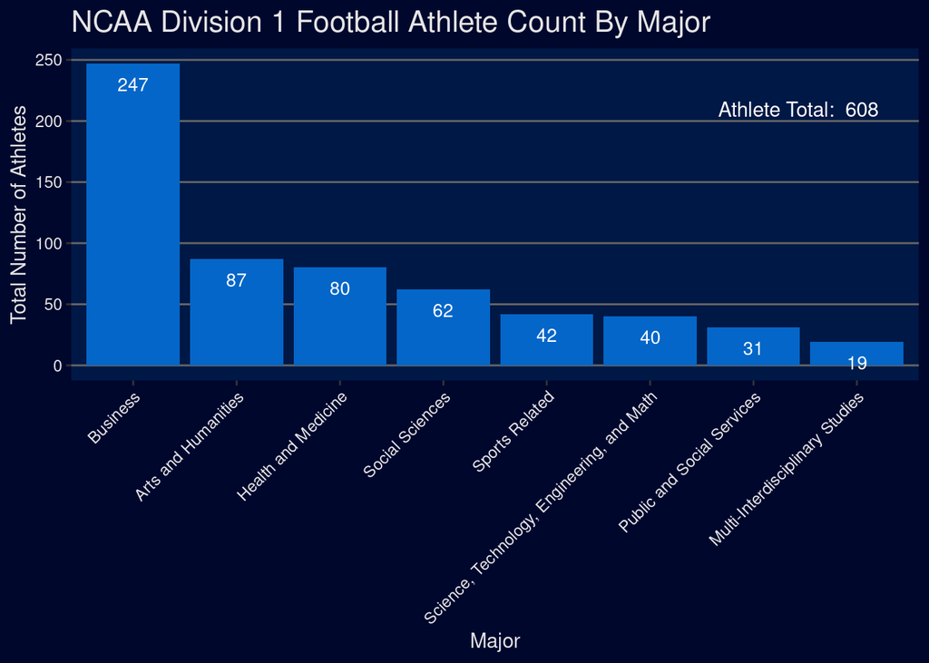

### Comparison of popular majors across different schools

To gain insight into the most popular majors among the student body of these colleges, I collected data from the [U.S. News Best Colleges](https://www.usnews.com/best-colleges) list. This source provided a comprehensive overview of the colleges and their respective majors, based on the percentage of students who graduate with each degree per year.

**#1. University of Georgia** **#4. Ohio State**

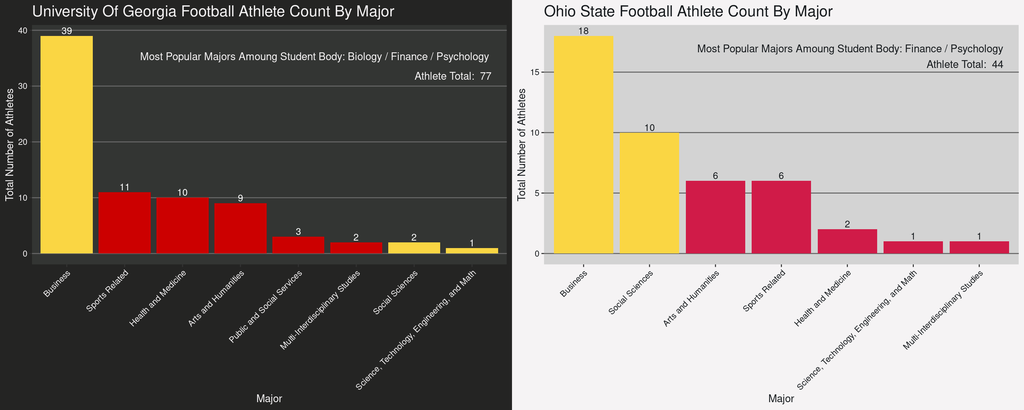

Overall, the two plots provide interesting insights into the distribution of majors among the chosen universities. The plot for University of Georgia suggests that the team has a significant number of Business majors which is consistent, but has the other two most popular majors in the lower end groups. While the Ohio State plot confirms that the university’s most popular majors, falling into the Business and Social Science categories, are indeed highly represented among their team.

**#6. University of Tennessee** **#7. Pennsylvania State University**

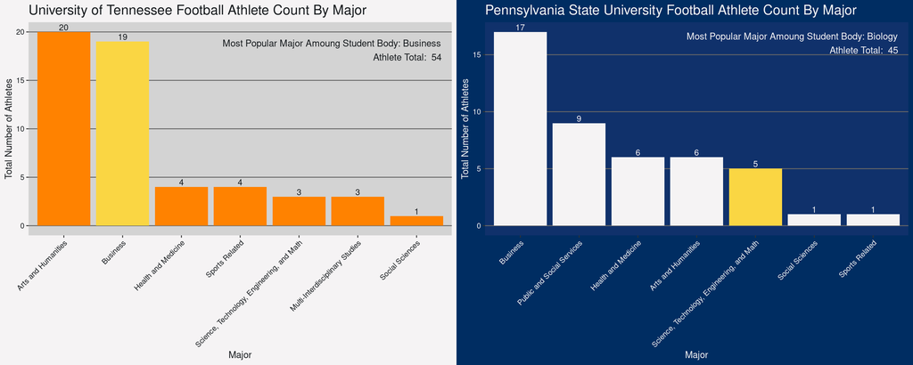

**#9. Tulane University** **#10. University of Utah**

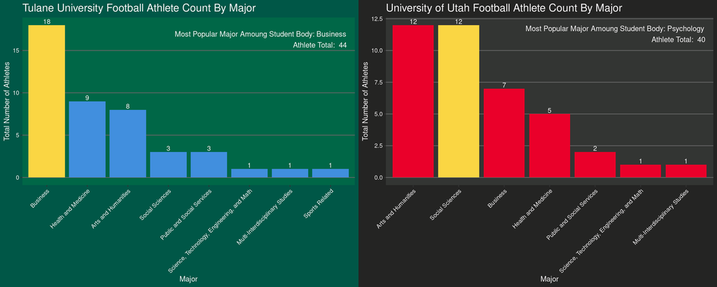

**#13. Clemson University** **#14. Kansas State**

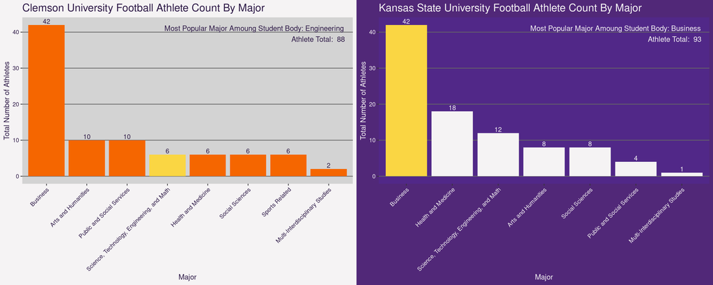

This analysis highlights significant differences in the major representation between the team and the student body. At Clemson University, Business dominates the team’s majors, whereas the school’s most popular major is Engineering. Meanwhile, Kansas State University’s most popular major is Business, which is reflected in the high number of athletes in that major compared to other categories.

**#17. Oregon State** **#25. University of Texas**

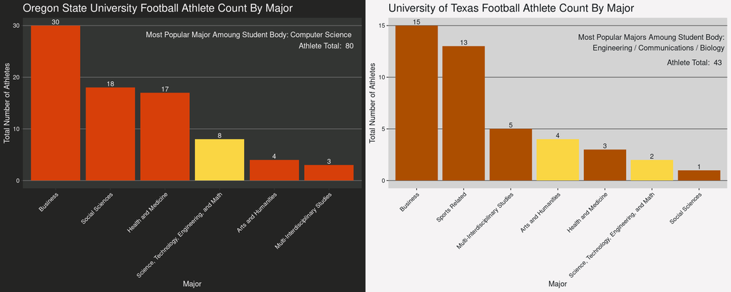

These two graphs align with the stereotype of athletes gravitating towards Business-related majors. At Oregon State, Business and Social Sciences are well-represented among athletes, but Computer Science (STEM), the school’s most popular majors, falls behind other categories. At the University of Texas, Business is the dominant major, which is understandable given the popularity of a Business-related major. However, it’s worth noting that two of the most popular majors ate the university are STEM-related, yet they are the least represented among athletes. Additionally, the presence of Sports-Related majors in the top two is notable.

Overall, the analysis of the graphs reveals that Business is the most dominant major among football players across the majority of the ten schools studied. While there are some variations, such as Social Sciences being the most popular major at University of Utah, Business remains at the top choice for most football players. These findings suggest that the stereotype of athletes gravitating towards business-related majors may hold some truth.

# Discussion

We are aiming to explore the academic choices of Division 1 football players and analyze the specialties of different schools when it comes to major choice. One question that arises is whether football players tend to opt for “easy” majors or if there are other factors that influence their academic decisions. Additionally, we will examine whether the stereotype of football players as primarily choosing Business-related majors holds true across all schools or if there any surprising results.

### How Do the Most Popular Majors at the Schools Affect the Major Choice of Football Players?

Based on the data, it appears that the most popular major at a school has little impact on the majors chosen by student-athletes. The majority of teams have a large proportion of players in major classified as “easy”, with Business being the most common, followed by Arts and Humanities. Since both of these categories are considered “easy” majors, it is reasonable to conclude that the most popular major at a school does not influence the choice of major among athletes.

### Do Division 1 Football Players Tend to Choose “Easy” Majors?

#### What is Considered an Easy Major?

Easy majors are a common topic of discussion, especially in relation to Division 1 football players. While the definition of an easy major may be subjective and influenced by various factors, such as the rigor of the school or individual circumstances, rankings such as those provided by [University HQ](https://universityhq.org/degrees/online-bachelors/easiest-college-majors/) are often cited. According to their data, the top five easiest majors fall under the categories of Business, Arts and Humanities, and Public and Social Services, with Business / Management being the easiest. However, it’s important to consider the limitations and biases of these rankings, such as the reliance on factors like graduate GPA data and student reviews.

#### Why Would an Athlete Choose an “Easy” Major?

When considering what might constitute an “easy” major, it’s important to acknowledge the demands placed on Division 1 student-athletes. As someone who played Division 3 football, I know firsthand how much time and effort goes into practices, meetings, and film sessions. For Division 1 athletes, this commitment can easily exceed 20 hours per week. According to a Flagler College Gargoyle [article](https://gargoyle.flagler.edu/2022/10/is-the-workload-too-much-for-student-athletes/#:~:text=College%20student%2Dathletes%20spend%20on,sleeping%2C%20according%20to%20the%20NCAA.), these student-athletes spend an average of just six hours on school work, 5.7 hours on athletic events, and 3.3 hours on social life, leaving roughly seven hours for sleep. Given this grueling schedule, it’s understandable why student-athletes might opt for majors that are less time-consuming or demanding. After all, their days are already longer and harder than most.

After analyzing the findings, it is evident that Division 1 football players gravitate towards “easy” majors. This trend is supported by the data, and can be attributed to their rigorous schedules or the possibility of burnout from their demanding commitments.

# Conclusion

Through a data-driven analysis of the academic paths of Division 1 football players, this article has explored the reality of stereotypes that suggest that athletes take the “easy road” when it comes to academics. As a former football player, this stereotype has fueled my curiosity to understand if it holds true. By examining patterns in major choice and comparing them to these stereotypes, this analysis has shed light on the academic paths of student-athletes and discussed the reality of commonly held beliefs. By the data analyzed in this article, it is safe to assume that these stereotypes hold true… Whether we want to believe it or not.

# Works Cited

[College Major Categories](https://bigfuture.collegeboard.org/explore-careers/majors#)  
[Most Popular Major By School](https://www.usnews.com/best-colleges)  
[Easiest College Majors](https://universityhq.org/degrees/online-bachelors/easiest-college-majors/)  
[Athletic Schedule Article](https://gargoyle.flagler.edu/2022/10/is-the-workload-too-much-for-student-athletes/#:~:text=College%20student%2Dathletes%20spend%20on,sleeping%2C%20according%20to%20the%20NCAA.) [University of Georgia Football Page](https://georgiadogs.com/sports/football)  
[Ohio State University Football Page](https://ohiostatebuckeyes.com/sports/m-footbl/)  
[University of Tennessee Football Page](https://utsports.com/sports/football)  
[Pennsylvania State University Football Page](https://gopsusports.com/sports/football)  
[Tulane University Football Page](https://tulanegreenwave.com/sports/football)  
[University of Utah Football Page](https://utahutes.com/sports/football)  
[Clemson University Football Page](https://clemsontigers.com/sports/football/)  
[Kansas State University Football Page](https://www.kstatesports.com/sports/football)  
[Oregon State University Football Page](https://osubeavers.com/sports/football)  
[University of Texas Football Page](https://texassports.com/sports/football)